# G0S2_taqman_analysis_notebook

Provides information about variables in the table.

```r
str(expression_table)
```

```
'data.frame':   83 obs. of  25 variables:
 $ ID                   : chr  "1" "13" "14" "142" ...
 $ Sample_Name          : chr  "PL1" "PL13" "PL14" "PL142" ...
 $ Target_Name          : chr  "G0S2" "G0S2" "G0S2" "G0S2" ...
 $ Fold_change          : num  0.476 1.196 0.944 1.19 1.247 ...
 $ Sample               : chr  "PL" "PL" "PL" "PL" ...
 $ Gestational_age      : chr  "Term" "Term" "Term" "PTLeve" ...
 $ Children_phenotype   : chr  "AGA" "AGA" "IUGR" "IUGR" ...
 $ Sex                  : chr  "Female" "Female" "Female" "Female" ...
 $ H19                  : num  11.43 15.45 6.08 3.5 2.18 ...
 $ IGF2                 : num  5.609 5.841 1.685 0.624 0.931 ...
 $ L19                  : num  1 1 1 1 1 1 1 1 1 1 ...
 $ Birth_weight         : num  3100 2720 3630 2030 1700 620 2320 1530 3380 1920 ...
 $ Age_mom              : num  33 36 31 41 32 32 34 34 36 41 ...
 $ Hight_mom            : num  156 160 172 166 NA NA NA 160 157 161 ...
 $ Moms_weight_start    : num  60 66 65 49 NA NA NA 67 68 100 ...
 $ Moms_weight_end      : num  83 70 79.1 69 NA NA NA 75 80 106 ...
 $ Mom_gained_weight    : num  23 4 14.1 20 NA NA NA 8 12 6 ...
 $ IVF                  : chr  "No" "No" "No" "Yes" ...
 $ Birth_type           : num  4 2 1 1 5 5 3 5 1 3 ...
 $ Gestational_age_weeks: num  40.9 38.7 39.6 36.7 33.3 ...
 $ Complications        : num  1 8 1 1 99 4 1 1 1 4 ...
 $ Smoking              : num  1 3 NA NA NA NA NA NA NA NA ...
 $ Smoking_n            : num  10 0 0 NA 0 0 20 0 5 10 ...
 $ na.strings           : chr  "NA" "NA" "NA" "NA" ...
 $ log2_Fold_change     : num  -1.071 0.2582 -0.0831 0.251 0.3185 ...
```

Covert variables to factors.

```r
expression_table$Children_phenotype <- factor(expression_table$Children_phenotype, levels=c('AGA', 'SGA', 'IUGR', 'PE'))
expression_table$Sex <- factor(expression_table$Sex, levels=c('Male', 'Female'))
expression_table$IVF <- factor(expression_table$IVF, levels=c('Yes', 'No'))
expression_table$Gestational_age <- factor(expression_table$Gestational_age, levels=c('Term', 'PTLeve', 'PTMod', 'PTExt'))
expression_table$Complications <- factor(expression_table$Complications, levels=c('1', '3', '4', '6', '7', '8', '9', '11', '15', '16', '99'))
```

Compare different variables.

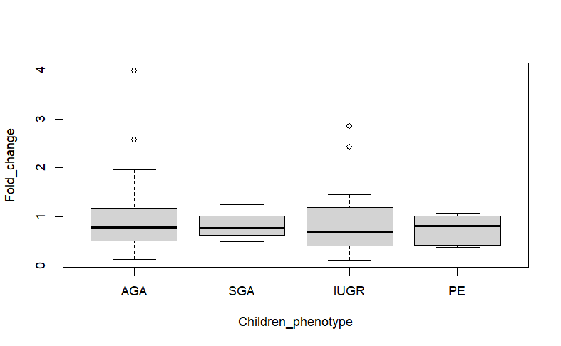

```r
plot(Fold_change ~ Children_phenotype, data= expression_table)
```

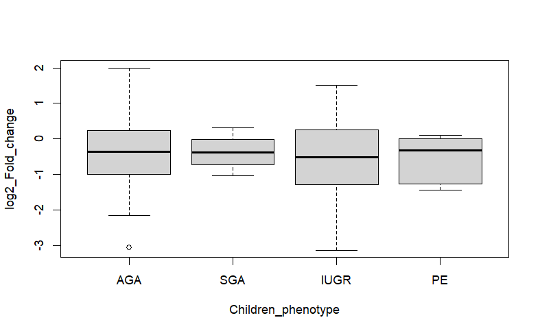

```r
plot(log2_Fold_change ~ Children_phenotype, data= expression_table)
```

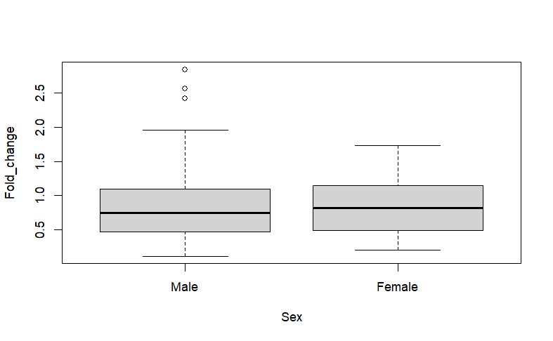

```r
plot(Fold_change ~ Sex, data= expression_table)
```

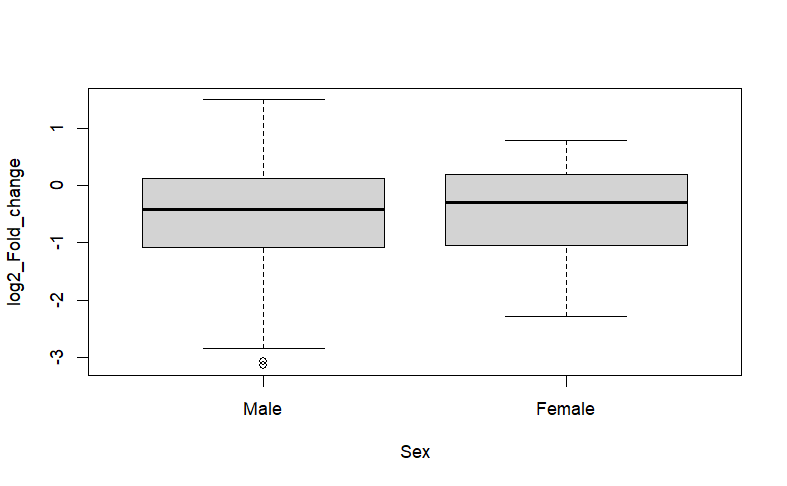

```r
plot(log2_Fold_change ~ Sex, data= expression_table)
```

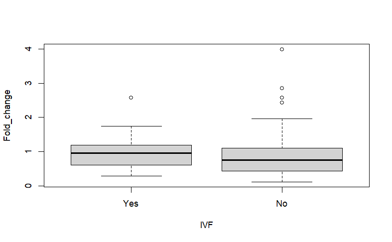

```r
plot(Fold_change ~ IVF, data= expression_table)
```

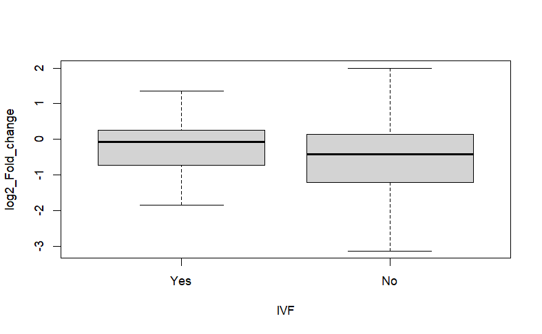

```r
plot(log2_Fold_change ~ IVF, data= expression_table)
```

```r
G0S2 <- expression_table
rm(expression_table)
```

Samples with expression data.

```r
G0S2$Sample_Name
```

```
 [1] "PL1"   "PL13"  "PL14"  "PL142" "PL143" "PL144" "PL146" "PL147" "PL15"  "PL152" "PL154" "PL155" "PL158" "PL159" "PL16"  "PL160"
[17] "PL161" "PL162" "PL163" "PL164" "PL165" "PL166" "PL167" "PL170" "PL18"  "PL186" "PL191" "PL20"  "PL21"  "PL216" "PL217" "PL22"
[33] "PL222" "PL225" "PL226" "PL23"  "PL26"  "PL3"   "PL34"  "PL36"  "PL37"  "PL41"  "PL42"  "PL43"  "PL44"  "PL45"  "PL47"  "PL49"
[49] "PL50"  "PL51"  "PL52"  "PL53"  "PL54"  "PL55"  "PL56"  "PL58"  "PL59"  "PL6"   "PL62"  "PL66"  "PL 67" "PL68"  "PL69"  "PL7"
[65] "PL71"  "PL72"  "PL73"  "PL74"  "PL75"  "PL78"  "PL79"  "PL8"   "PL80"  "PL87"  "PL88"  "PL89"  "PL9"   "PL90"  "PL91"  "PL93"
[81] "PL94"  "PL97"  "PL98"
```

Total number of samples with expression data.

```r
length(G0S2$Sample_Name)
```

```
[1] 83
```

Check residual distribution.

```r
fit <- lm(log2_Fold_change ~ Children_phenotype, data = G0S2)
summary(fit)
```

```
Call:
lm(formula = log2_Fold_change ~ Children_phenotype, data = G0S2)

Residuals:
     Min       1Q   Median       3Q      Max
-2.71372 -0.66724  0.03562  0.60718  2.35364

Coefficients:
                       Estimate Std. Error t value Pr(>|t|)
(Intercept)            -0.35725    0.14446  -2.473   0.0155 *
Children_phenotypeSGA  -0.01106    0.52086  -0.021   0.9831
Children_phenotypeIUGR -0.27783    0.25768  -1.078   0.2842
Children_phenotypePE   -0.20744    0.36355  -0.571   0.5699
---
Signif. codes:  0 ‘***’ 0.001 ‘**’ 0.01 ‘*’ 0.05 ‘.’ 0.1 ‘ ’ 1

Residual standard error: 1.001 on 79 degrees of freedom
Multiple R-squared:  0.01629,   Adjusted R-squared:  -0.02107
F-statistic: 0.436 on 3 and 79 DF,  p-value: 0.7278
```

```r
residual_G0S2_table <- G0S2 %>% filter(!Children_phenotype %in% c(NA))
residual_G0S2_table$predicted <- predict(fit)   # Save the predicted values
residual_G0S2_table$residuals <- residuals(fit) # Save the residual values

#Reorder the group order: in figures, cell order should change from the default
residual_G0S2_table$Children_phenotype <- factor(residual_G0S2_table$Children_phenotype, levels=c("AGA", "IUGR", "SGA", "PE"))
```

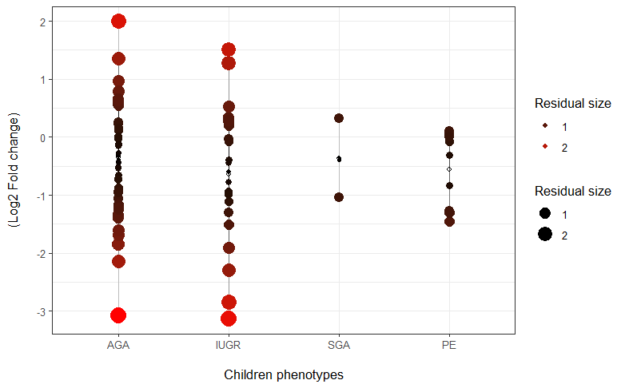

```r
G0S2_residuals <- ggplot(residual_G0S2_table, aes(x = Children_phenotype, y = as.numeric(log2_Fold_change))) +
   geom_segment(aes(xend = Children_phenotype, yend = predicted), alpha = .2) +
   geom_point(aes(colour = abs(residuals), size = abs(residuals))) +
   scale_color_continuous(low = "black", high = "red") +
   guides(alpha = 'none') +
   geom_point(aes(y = predicted), shape = 1)+  # Add the predicted values
   theme_bw() +
   guides(col=guide_legend("Residual size "),
          size=guide_legend("Residual size"))+
   xlab("\nChildren phenotypes") +
   ylab("(Log2 Fold change)\n")
G0S2_residuals
```

```r
required_column = G0S2$Fold_change
```

Calculate upper and lower quartiles to know which samples are outliers for expression.

```r
lowerq = quantile(required_column)[2]
lowerq
```

```
   25%
0.4795
```

```r
upperq = quantile(required_column)[4]
upperq
```

```
  75%
1.133
```

```r
iqr = upperq - lowerq #Or use IQR(data)
iqr
```

```
   75%
0.6535
```

Check outliers based on upper(75%) and lower(25%) quartiles.

```r
G0S2_outiers1 <- dplyr::filter(G0S2, Fold_change < lowerq)
summary(G0S2_outiers1)
```

```
      ID            Sample_Name        Target_Name         Fold_change        Sample          Gestational_age Children_phenotype
 Length:21          Length:21          Length:21          Min.   :0.1140   Length:21          Term  :10       AGA :11
 Class :character   Class :character   Class :character   1st Qu.:0.2670   Class :character   PTLeve: 2       SGA : 0
 Mode  :character   Mode  :character   Mode  :character   Median :0.3660   Mode  :character   PTMod : 5       IUGR: 7
                                                          Mean   :0.3308                      PTExt : 4       PE  : 3
                                                          3rd Qu.:0.4150
                                                          Max.   :0.4760

     Sex          H19               IGF2            L19     Birth_weight     Age_mom        Hight_mom     Moms_weight_start
 Male  : 9   Min.   : 0.6659   Min.   :0.203   Min.   :1   Min.   : 700   Min.   :22.00   Min.   :143.0   Min.   :44.00
 Female:10   1st Qu.: 3.5111   1st Qu.:0.747   1st Qu.:1   1st Qu.:1285   1st Qu.:27.50   1st Qu.:158.0   1st Qu.:50.00
 NA's  : 2   Median : 5.2709   Median :1.221   Median :1   Median :1830   Median :32.00   Median :160.0   Median :60.00
             Mean   : 5.2989   Mean   :1.751   Mean   :1   Mean   :2062   Mean   :31.47   Mean   :160.8   Mean   :59.53
             3rd Qu.: 6.8884   3rd Qu.:2.423   3rd Qu.:1   3rd Qu.:2795   3rd Qu.:34.00   3rd Qu.:165.0   3rd Qu.:68.00
             Max.   :12.6477   Max.   :5.609   Max.   :1   Max.   :3760   Max.   :43.00   Max.   :176.0   Max.   :85.00
             NA's   :1         NA's   :1       NA's   :1   NA's   :2      NA's   :2       NA's   :4       NA's   :4
 Moms_weight_end Mom_gained_weight   IVF       Birth_type  Gestational_age_weeks Complications    Smoking        Smoking_n
 Min.   :54.20   Min.   : 7.00     Yes : 2   Min.   :1.0   Min.   :26.00         1      :10    Min.   : 0.00   Min.   : 0.000
 1st Qu.:63.00   1st Qu.: 9.55     No  :18   1st Qu.:1.0   1st Qu.:32.22         6      : 3    1st Qu.: 1.25   1st Qu.: 0.000
 Median :74.50   Median :12.00     NA's: 1   Median :3.0   Median :36.86         4      : 2    Median : 2.00   Median : 0.000
 Mean   :72.81   Mean   :12.68               Mean   :3.0   Mean   :35.46         7      : 2    Mean   : 2.70   Mean   : 1.353
 3rd Qu.:83.00   3rd Qu.:14.25               3rd Qu.:4.5   3rd Qu.:39.25         3      : 1    3rd Qu.: 3.00   3rd Qu.: 1.000
 Max.   :92.00   Max.   :23.00               Max.   :6.0   Max.   :41.00         (Other): 1    Max.   :10.00   Max.   :10.000
 NA's   :5       NA's   :5                   NA's   :2     NA's   :7             NA's   : 2    NA's   :11      NA's   :4
  na.strings        log2_Fold_change
 Length:21          Min.   :-3.133
 Class :character   1st Qu.:-1.905
 Mode  :character   Median :-1.450
                    Mean   :-1.709
                    3rd Qu.:-1.269
                    Max.   :-1.071
```

```r
G0S2_outiers1
```

| ID | Sample_Name | Target_Name | Fold_change | Sample | Gestational_age | Children_phenotype | Sex | H19 | IGF2 | L19 | Birth_weight | Age_mom | Hight_mom | Moms_weight_start | Moms_weight_end | Mom_gained_weight | IVF | Birth_type | Gestational_age_weeks | Complications | Smoking | Smoking_n | na.strings | log2_Fold_change |
| --- | --- | --- | --- | --- | --- | --- | --- | --- | --- | --- | --- | --- | --- | --- | --- | --- | --- | --- | --- | --- | --- | --- | --- | --- |
| 1 | PL1 | G0S2 | 0.476 | PL | Term | AGA | Female | 11.4293623 | 5.6090301 | 1 | 3100 | 33 | 156 | 60 | 83.0 | 23.0 | No | 4 | 40.86000 | 1 | 1 | 10 | NA | -1.070966 |
| 147 | PL147 | G0S2 | 0.381 | PL | PTMod | AGA | Female | 4.5647832 | 3.5338252 | 1 | 1530 | 34 | 160 | 67 | 75.0 | 8.0 | No | 5 | 32.86000 | 1 | NA | 0 | NA | -1.392137 |
| 154 | PL154 | G0S2 | 0.464 | PL | PTLeve | IUGR | Male | 7.5864415 | 4.5493549 | 1 | 2510 | 31 | 158 | 44 | 56.0 | 12.0 | No | 6 | 35.57000 | 1 | 2 | 0 | NA | -1.107803 |
| 160 | PL160 | G0S2 | 0.407 | PL | Term | IUGR | Female | 1.3248610 | 0.3397544 | 1 | 1450 | 38 | 154 | 46 | 54.2 | 8.2 | No | 2 | 38.14286 | 1 | 10 | 1 | NA | -1.296899 |
| 161 | PL161 | G0S2 | 0.205 | PL | Term | IUGR | Female | 5.4272561 | 2.6939467 | 1 | 1670 | 31 | 160 | 68 | 79.7 | 11.7 | No | 1 | 39.42857 | 1 | 0 | 1 | NA | -2.286304 |
| 167 | PL167 | G0S2 | 0.366 | PL | PTMod | PE | NA | 1.0195826 | 0.2030072 | 1 | 810 | NA | NA | NA | NA | NA | No | NA | NA | 4 | NA | 0 | NA | -1.450084 |
| 18 | PL18 | G0S2 | 0.396 | PL | Term | AGA | Female | 5.1146068 | 2.7340899 | 1 | 3760 | 28 | 150 | 45 | 57.0 | 12.0 | No | 1 | 38.42857 | 1 | 2 | 2 | NA | -1.336428 |
| 226 | PL226 | G0S2 | 0.226 | PL | Term | AGA | NA | 0.6659283 | 0.2132726 | 1 | 2690 | NA | NA | NA | NA | NA | NA | NA | NA | 1 | NA | 4 | NA | -2.145605 |
| 23 | PL23 | G0S2 | 0.119 | PL | Term | AGA | Male | 4.3455978 | 1.0652628 | 1 | 1535 | 34 | 167 | 68 | 83.0 | 15.0 | No | 6 | 40.42857 | 6 | NA | 0 | NA | -3.070966 |
| 34 | PL34 | G0S2 | 0.421 | PL | Term | AGA | Male | 4.1545983 | 1.1018868 | 1 | 1830 | 24 | 159 | 85 | 92.0 | 7.0 | No | 3 | 38.71000 | 11 | NA | 0 | NA | -1.248108 |

[output cut: 11 more lines]

```r
G0S2_outiers2 <- dplyr::filter(G0S2, Fold_change > upperq)
summary(G0S2_outiers2)
```

```
      ID            Sample_Name        Target_Name         Fold_change       Sample          Gestational_age Children_phenotype
 Length:21          Length:21          Length:21          Min.   :1.149   Length:21          Term  :6        AGA :13
 Class :character   Class :character   Class :character   1st Qu.:1.214   Class :character   PTLeve:7        SGA : 1
 Mode  :character   Mode  :character   Mode  :character   Median :1.478   Mode  :character   PTMod :2        IUGR: 7
                                                          Mean   :1.750                      PTExt :6        PE  : 0
                                                          3rd Qu.:1.962
                                                          Max.   :3.990

     Sex          H19              IGF2             L19     Birth_weight     Age_mom        Hight_mom     Moms_weight_start
 Male  : 8   Min.   : 1.223   Min.   :0.1187   Min.   :1   Min.   :1150   Min.   :24.00   Min.   :154.0   Min.   :48.00
 Female:11   1st Qu.: 3.712   1st Qu.:1.2824   1st Qu.:1   1st Qu.:1870   1st Qu.:30.00   1st Qu.:161.8   1st Qu.:60.75
 NA's  : 2   Median : 4.873   Median :1.7547   Median :1   Median :2240   Median :32.00   Median :164.5   Median :64.00
             Mean   : 5.677   Mean   :2.0939   Mean   :1   Mean   :2249   Mean   :33.63   Mean   :165.8   Mean   :65.06
             3rd Qu.: 7.420   3rd Qu.:2.8465   3rd Qu.:1   3rd Qu.:2490   3rd Qu.:37.00   3rd Qu.:171.0   3rd Qu.:70.00
             Max.   :15.448   Max.   :5.8411   Max.   :1   Max.   :3840   Max.   :46.00   Max.   :177.0   Max.   :82.00
             NA's   :1        NA's   :1        NA's   :1                  NA's   :2       NA's   :5       NA's   :5
 Moms_weight_end Mom_gained_weight   IVF       Birth_type Gestational_age_weeks Complications    Smoking      Smoking_n
 Min.   :62.00   Min.   :-1.00     Yes : 7   Min.   :1    Min.   :27.29         1      :16    Min.   :0.0   Min.   : 0.000
 1st Qu.:69.00   1st Qu.: 8.00     No  :13   1st Qu.:1    1st Qu.:34.00         7      : 1    1st Qu.:0.5   1st Qu.: 0.000
 Median :74.00   Median :10.00     NA's: 1   Median :3    Median :36.22         8      : 1    Median :2.0   Median : 0.000
 Mean   :76.23   Mean   :11.17               Mean   :3    Mean   :35.74         9      : 1    Mean   :1.6   Mean   : 3.176
 3rd Qu.:82.17   3rd Qu.:16.12               3rd Qu.:5    3rd Qu.:38.71         11     : 1    3rd Qu.:2.0   3rd Qu.: 2.000
 Max.   :94.50   Max.   :22.70               Max.   :6    Max.   :40.29         99     : 1    Max.   :3.0   Max.   :20.000
 NA's   :5       NA's   :5                   NA's   :2    NA's   :3             (Other): 0    NA's   :11    NA's   :4
  na.strings        log2_Fold_change
 Length:21          Min.   :0.2004
 Class :character   1st Qu.:0.2798
 Mode  :character   Median :0.5636
                    Mean   :0.7110
                    3rd Qu.:0.9723
                    Max.   :1.9964
```

```r
G0S2_outiers2
```

| ID | Sample_Name | Target_Name | Fold_change | Sample | Gestational_age | Children_phenotype | Sex | H19 | IGF2 | L19 | Birth_weight | Age_mom | Hight_mom | Moms_weight_start | Moms_weight_end | Mom_gained_weight | IVF | Birth_type | Gestational_age_weeks | Complications | Smoking | Smoking_n | na.strings | log2_Fold_change |
| --- | --- | --- | --- | --- | --- | --- | --- | --- | --- | --- | --- | --- | --- | --- | --- | --- | --- | --- | --- | --- | --- | --- | --- | --- |
| 13 | PL13 | G0S2 | 1.196 | PL | Term | AGA | Female | 15.448337 | 5.8411024 | 1 | 2720 | 36 | 160 | 66 | 70.0 | 4.0 | No | 2 | 38.71429 | 8 | 3 | 0 | NA | 0.2582174 |
| 142 | PL142 | G0S2 | 1.190 | PL | PTLeve | IUGR | Female | 3.496025 | 0.6236991 | 1 | 2030 | 41 | 166 | 49 | 69.0 | 20.0 | Yes | 1 | 36.71429 | 1 | NA | NA | NA | 0.2509616 |
| 143 | PL143 | G0S2 | 1.247 | PL | PTMod | SGA | Female | 2.177367 | 0.9311105 | 1 | 1700 | 32 | NA | NA | NA | NA | Yes | 5 | 33.28571 | 99 | NA | 0 | NA | 0.3184614 |
| 146 | PL146 | G0S2 | 1.962 | PL | Term | AGA | Male | 5.322437 | 3.4856539 | 1 | 2320 | 34 | NA | NA | NA | NA | No | 3 | 38.71429 | 1 | NA | 20 | NA | 0.9723251 |
| 159 | PL159 | G0S2 | 1.735 | PL | PTLeve | AGA | Female | 3.076413 | 1.6492266 | 1 | 1770 | 32 | 172 | 60 | 82.7 | 22.7 | Yes | 3 | 34.71429 | 9 | 2 | 10 | NA | 0.7949357 |
| 16 | PL16 | G0S2 | 1.453 | PL | Term | AGA | Female | 10.036753 | 3.8136585 | 1 | 1980 | 35 | 170 | 69 | 77.0 | 8.0 | No | 1 | 40.00000 | 11 | NA | 10 | NA | 0.5390347 |
| 163 | PL163 | G0S2 | 1.478 | PL | PTLeve | AGA | Female | 3.476445 | 1.4020269 | 1 | 2490 | 30 | 177 | 78 | 94.5 | 16.5 | Yes | 3 | 34.00000 | 1 | 0 | 1 | NA | 0.5636463 |
| 164 | PL164 | G0S2 | 2.569 | PL | PTLeve | AGA | Male | 4.812653 | 2.0832404 | 1 | 2520 | 30 | 177 | 78 | 94.5 | 16.5 | Yes | 3 | 34.00000 | 1 | NA | 0 | NA | 1.3612069 |
| 166 | PL166 | G0S2 | 3.990 | PL | PTExt | AGA | NA | 4.740799 | 1.8205214 | 1 | 1150 | NA | NA | NA | NA | NA | No | NA | NA | 1 | NA | 0 | NA | 1.9963887 |
| 217 | PL217 | G0S2 | 1.258 | PL | PTExt | IUGR | NA | 1.222955 | 0.1186941 | 1 | 2270 | NA | NA | NA | NA | NA | NA | NA | NA | 1 | 2 | 1 | NA | 0.3311319 |

[output cut: 11 more lines]

Distributions:

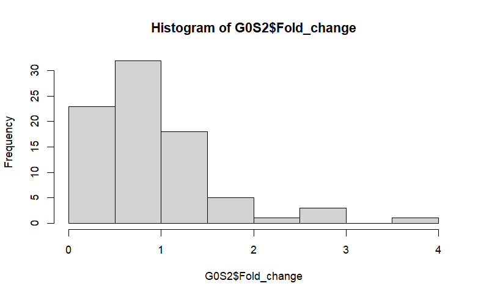

```r
hist(G0S2$Fold_change)
```

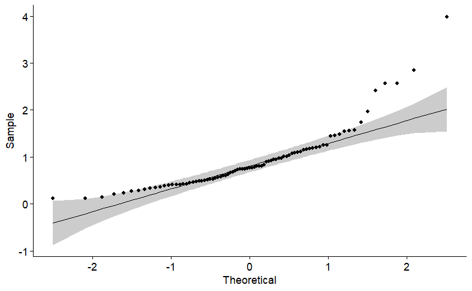

```r
ggqqplot(G0S2$Fold_change)
```

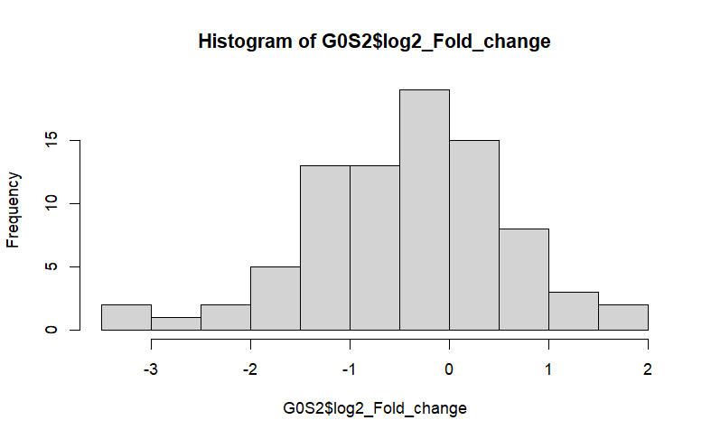

```r
hist(G0S2$log2_Fold_change)
```

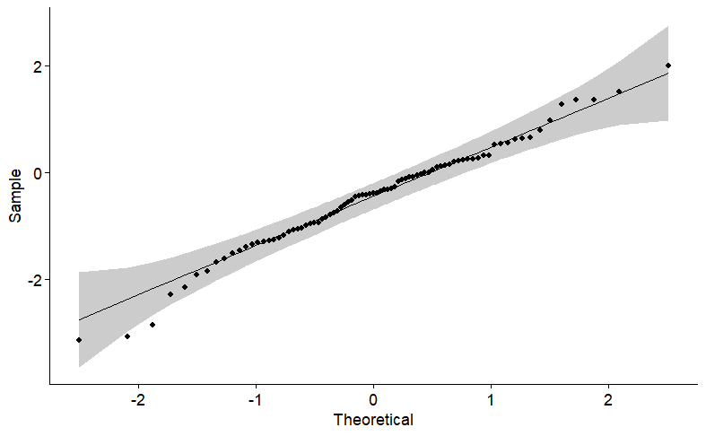

```r
ggqqplot(G0S2$log2_Fold_change)
```

```r
nrow(G0S2)
```

```
[1] 83
```

log transformation normalises the data.

# Merge qPCR data with methylation data

```r
Gene1_filtered_table$ID <- as.character(Gene1_filtered_table$ID)
```

```r
G0S2$Sample_Name <- as.character(G0S2$Sample_Name)
```

```r
G0S2$Birth_type <- factor(G0S2$Birth_type, levels=c('1', '2', '3', '4', '5', '6'))
```

```r
G0S2_combined_table <- full_join(G0S2, Gene1_filtered_table, by=c("ID" = "ID"))
```

```r
G0S2_combined_table
```

| ID | Sample_Name | Target_Name | Fold_change | Sample | Gestational_age | Children_phenotype | Sex | H19 | IGF2 | L19 | Birth_weight | Age_mom | Hight_mom | Moms_weight_start | Moms_weight_end | Mom_gained_weight | IVF | Birth_type | Gestational_age_weeks | Complications | Smoking | Smoking_n | na.strings | log2_Fold_change | Original_name | CpG1 | CpG2 | CpG3 | CpG4 | … |
| --- | --- | --- | --- | --- | --- | --- | --- | --- | --- | --- | --- | --- | --- | --- | --- | --- | --- | --- | --- | --- | --- | --- | --- | --- | --- | --- | --- | --- | --- | --- |
| 1 | PL1 | G0S2 | 0.476 | PL | Term | AGA | Female | 11.4293623 | 5.60903013 | 1 | 3100 | 33 | 156 | 60.0 | 83.0 | 23.0 | No | 4 | 40.86000 | 1 | 1 | 10 | NA | -1.070966488 | PL001 | 46.87 | 37.93 | 37.41 | 35.56 | … |
| 13 | PL13 | G0S2 | 1.196 | PL | Term | AGA | Female | 15.4483373 | 5.84110236 | 1 | 2720 | 36 | 160 | 66.0 | 70.0 | 4.0 | No | 2 | 38.71429 | 8 | 3 | 0 | NA | 0.258217365 | PL013 | 45.73 | 31.02 | 29.58 | 30.12 | … |
| 14 | PL14 | G0S2 | 0.944 | PL | Term | IUGR | Female | 6.0822692 | 1.68544631 | 1 | 3630 | 31 | 172 | 65.0 | 79.1 | 14.1 | No | 1 | 39.57000 | 1 | NA | 0 | NA | -0.083141227 | PL014 | 33.40 | 19.97 | 19.09 | 16.76 | … |
| 142 | PL142 | G0S2 | 1.190 | PL | PTLeve | IUGR | Female | 3.4960246 | 0.62369906 | 1 | 2030 | 41 | 166 | 49.0 | 69.0 | 20.0 | Yes | 1 | 36.71429 | 1 | NA | NA | NA | 0.250961643 | NA | NA | NA | NA | NA | … |
| 143 | PL143 | G0S2 | 1.247 | PL | PTMod | SGA | Female | 2.1773666 | 0.93111052 | 1 | 1700 | 32 | NA | NA | NA | NA | Yes | 5 | 33.28571 | 99 | NA | 0 | NA | 0.318461441 | PL143 | 38.67 | 41.44 | 28.86 | 51.39 | … |
| 144 | PL144 | G0S2 | 0.948 | PL | PTMod | PE | Female | 3.2497130 | 1.47615205 | 1 | 620 | 32 | NA | NA | NA | NA | Yes | 5 | 33.28571 | 4 | NA | 0 | NA | -0.077041015 | PL144 | 70.75 | 60.48 | 56.58 | 59.18 | … |
| 146 | PL146 | G0S2 | 1.962 | PL | Term | AGA | Male | 5.3224371 | 3.48565391 | 1 | 2320 | 34 | NA | NA | NA | NA | No | 3 | 38.71429 | 1 | NA | 20 | NA | 0.972325051 | PL146 | 47.90 | 41.02 | 39.91 | 40.15 | … |
| 147 | PL147 | G0S2 | 0.381 | PL | PTMod | AGA | Female | 4.5647832 | 3.53382517 | 1 | 1530 | 34 | 160 | 67.0 | 75.0 | 8.0 | No | 5 | 32.86000 | 1 | NA | 0 | NA | -1.392137051 | NA | NA | NA | NA | NA | … |
| 15 | PL15 | G0S2 | 0.972 | PL | Term | AGA | Female | 11.7839202 | 4.03713827 | 1 | 3380 | 36 | 157 | 68.0 | 80.0 | 12.0 | No | 1 | 38.71429 | 1 | NA | 5 | NA | -0.040971777 | PL015 | 41.37 | 26.70 | 20.67 | 23.56 | … |
| 152 | PL152 | G0S2 | 1.074 | PL | PTLeve | PE | Female | 9.7542819 | 5.22401486 | 1 | 1920 | 41 | 161 | 100.0 | 106.0 | 6.0 | Yes | 3 | 34.86000 | 4 | NA | 10 | NA | 0.102993995 | PL152 | 41.76 | 36.74 | 34.27 | 36.10 | … |

[output cut: 73 more lines]

Covert variables to factors or characters to numbers. This function converts data to factors or numbers.

```r
conert_data_types <- function(data_table_input){

  data_table_input$Children_phenotype <- factor(data_table_input$Children_phenotype, levels=c('AGA', 'SGA', 'IUGR', 'PE'))
  data_table_input$Sex<- factor(data_table_input$Sex, levels=c('Male', 'Female'))
  data_table_input$IVF <- factor(data_table_input$IVF, levels=c('Yes', 'No'))
  data_table_input$Gestational_age <- factor(data_table_input$Gestational_age, levels=c('Term', 'PTLeve', 'PTMod', 'PTExt'))
  data_table_input$Complications <- factor(data_table_input$Complications, levels=c('1', '3', '4', '6', '7', '8', '9', '11', '15', '16', '99'))
  data_table_input$Fold_change <- as.numeric(data_table_input$Fold_change)
  #data_table_input$RQ <- as.numeric(data_table_input$RQ)
  data_table_input$log2_Fold_change <- as.numeric(data_table_input$log2_Fold_change)

  ## this command in necessary, as otherwise returns a vector with the last value.
  return(data_table_input)
}
```

Returns tables with changed data types in several columns.

```r
G0S2_combined_table <- conert_data_types(data_table_input= G0S2_combined_table)
G0S2_combined_table
```

| ID | Sample_Name | Target_Name | Fold_change | Sample | Gestational_age | Children_phenotype | Sex | H19 | IGF2 | L19 | Birth_weight | Age_mom | Hight_mom | Moms_weight_start | Moms_weight_end | Mom_gained_weight | IVF | Birth_type | Gestational_age_weeks | Complications | Smoking | Smoking_n | na.strings | log2_Fold_change | Original_name | CpG1 | CpG2 | CpG3 | CpG4 | … |
| --- | --- | --- | --- | --- | --- | --- | --- | --- | --- | --- | --- | --- | --- | --- | --- | --- | --- | --- | --- | --- | --- | --- | --- | --- | --- | --- | --- | --- | --- | --- |
| 1 | PL1 | G0S2 | 0.476 | PL | Term | AGA | Female | 11.4293623 | 5.60903013 | 1 | 3100 | 33 | 156 | 60.0 | 83.0 | 23.0 | No | 4 | 40.86000 | 1 | 1 | 10 | NA | -1.070966488 | PL001 | 46.87 | 37.93 | 37.41 | 35.56 | … |
| 13 | PL13 | G0S2 | 1.196 | PL | Term | AGA | Female | 15.4483373 | 5.84110236 | 1 | 2720 | 36 | 160 | 66.0 | 70.0 | 4.0 | No | 2 | 38.71429 | 8 | 3 | 0 | NA | 0.258217365 | PL013 | 45.73 | 31.02 | 29.58 | 30.12 | … |
| 14 | PL14 | G0S2 | 0.944 | PL | Term | IUGR | Female | 6.0822692 | 1.68544631 | 1 | 3630 | 31 | 172 | 65.0 | 79.1 | 14.1 | No | 1 | 39.57000 | 1 | NA | 0 | NA | -0.083141227 | PL014 | 33.40 | 19.97 | 19.09 | 16.76 | … |
| 142 | PL142 | G0S2 | 1.190 | PL | PTLeve | IUGR | Female | 3.4960246 | 0.62369906 | 1 | 2030 | 41 | 166 | 49.0 | 69.0 | 20.0 | Yes | 1 | 36.71429 | 1 | NA | NA | NA | 0.250961643 | NA | NA | NA | NA | NA | … |
| 143 | PL143 | G0S2 | 1.247 | PL | PTMod | SGA | Female | 2.1773666 | 0.93111052 | 1 | 1700 | 32 | NA | NA | NA | NA | Yes | 5 | 33.28571 | 99 | NA | 0 | NA | 0.318461441 | PL143 | 38.67 | 41.44 | 28.86 | 51.39 | … |
| 144 | PL144 | G0S2 | 0.948 | PL | PTMod | PE | Female | 3.2497130 | 1.47615205 | 1 | 620 | 32 | NA | NA | NA | NA | Yes | 5 | 33.28571 | 4 | NA | 0 | NA | -0.077041015 | PL144 | 70.75 | 60.48 | 56.58 | 59.18 | … |
| 146 | PL146 | G0S2 | 1.962 | PL | Term | AGA | Male | 5.3224371 | 3.48565391 | 1 | 2320 | 34 | NA | NA | NA | NA | No | 3 | 38.71429 | 1 | NA | 20 | NA | 0.972325051 | PL146 | 47.90 | 41.02 | 39.91 | 40.15 | … |
| 147 | PL147 | G0S2 | 0.381 | PL | PTMod | AGA | Female | 4.5647832 | 3.53382517 | 1 | 1530 | 34 | 160 | 67.0 | 75.0 | 8.0 | No | 5 | 32.86000 | 1 | NA | 0 | NA | -1.392137051 | NA | NA | NA | NA | NA | … |
| 15 | PL15 | G0S2 | 0.972 | PL | Term | AGA | Female | 11.7839202 | 4.03713827 | 1 | 3380 | 36 | 157 | 68.0 | 80.0 | 12.0 | No | 1 | 38.71429 | 1 | NA | 5 | NA | -0.040971777 | PL015 | 41.37 | 26.70 | 20.67 | 23.56 | … |
| 152 | PL152 | G0S2 | 1.074 | PL | PTLeve | PE | Female | 9.7542819 | 5.22401486 | 1 | 1920 | 41 | 161 | 100.0 | 106.0 | 6.0 | Yes | 3 | 34.86000 | 4 | NA | 10 | NA | 0.102993995 | PL152 | 41.76 | 36.74 | 34.27 | 36.10 | … |

[output cut: 73 more lines]

Change a column name.

```r
names(G0S2_combined_table)[36] <- paste("CpG_average")
```

Test individual groups if data is normally distributed.

Test for normality, but only good for bigger samples, starting from 50 and up.

```r
input_table= G0S2_combined_table #log2 transformation helps

ks.test(input_table$Fold_change, "pnorm", mean=mean(input_table$Fold_change), sd=sd(input_table$Fold_change))
```

```
    Asymptotic one-sample Kolmogorov-Smirnov test

data:  input_table$Fold_change
D = 0.14114, p-value = 0.07326
alternative hypothesis: two-sided
```

```r
ks.test(input_table$log2_Fold_change, "pnorm", mean=mean(input_table$log2_Fold_change), sd=sd(input_table$log2_Fold_change))
```

```
    Asymptotic one-sample Kolmogorov-Smirnov test

data:  input_table$log2_Fold_change
D = 0.070186, p-value = 0.8082
alternative hypothesis: two-sided
```

The placenta samples that have good qRT-PCR values.

```r
G0S2_combined_table$Sample_Name
```

```
 [1] "PL1"   "PL13"  "PL14"  "PL142" "PL143" "PL144" "PL146" "PL147" "PL15"  "PL152" "PL154" "PL155" "PL158" "PL159" "PL16"  "PL160"
[17] "PL161" "PL162" "PL163" "PL164" "PL165" "PL166" "PL167" "PL170" "PL18"  "PL186" "PL191" "PL20"  "PL21"  "PL216" "PL217" "PL22"
[33] "PL222" "PL225" "PL226" "PL23"  "PL26"  "PL3"   "PL34"  "PL36"  "PL37"  "PL41"  "PL42"  "PL43"  "PL44"  "PL45"  "PL47"  "PL49"
[49] "PL50"  "PL51"  "PL52"  "PL53"  "PL54"  "PL55"  "PL56"  "PL58"  "PL59"  "PL6"   "PL62"  "PL66"  "PL 67" "PL68"  "PL69"  "PL7"
[65] "PL71"  "PL72"  "PL73"  "PL74"  "PL75"  "PL78"  "PL79"  "PL8"   "PL80"  "PL87"  "PL88"  "PL89"  "PL9"   "PL90"  "PL91"  "PL93"
[81] "PL94"  "PL97"  "PL98"
```

The placenta samples that have good qRT-PCR and pyrosequencing values.

```r
df <- G0S2_combined_table %>% filter(!methyl_status %in% c(NA))
df$Sample_Name
```

```
 [1] "PL1"   "PL13"  "PL14"  "PL143" "PL144" "PL146" "PL15"  "PL152" "PL155" "PL158" "PL159" "PL16"  "PL160" "PL161" "PL162" "PL163"
[17] "PL164" "PL165" "PL166" "PL167" "PL170" "PL18"  "PL186" "PL20"  "PL217" "PL22"  "PL222" "PL225" "PL23"  "PL26"  "PL34"  "PL36"
[33] "PL37"  "PL41"  "PL42"  "PL43"  "PL44"  "PL45"  "PL47"  "PL49"  "PL50"  "PL51"  "PL54"  "PL55"  "PL56"  "PL58"  "PL59"  "PL6"
[49] "PL62"  "PL66"  "PL69"  "PL7"   "PL71"  "PL72"  "PL73"  "PL74"  "PL75"  "PL78"  "PL79"  "PL8"   "PL80"  "PL88"  "PL89"  "PL9"
[65] "PL90"  "PL91"  "PL93"  "PL94"  "PL97"  "PL98"
```

For individual group comparisons can use parametric t. test if use log2 transformed data, or wilcox to keep the same statistical test for both genes.

```r
## Merge all tables to get one table with all genes in it
merged_table3 <- G0S2_combined_table

which(is.na(merged_table3$methyl_status))
```

```
 [1]  4  8 11 27 29 30 35 38 51 52 61 62 74
```

```r
length(which(is.na(merged_table3$methyl_status)))
```

```
[1] 13
```

Samples that don’t have pyro data, to keep them in expression plots.

```r
## fills empty rows, required for graphs, requires numbers not characters
for (i in c(4, 8, 11, 27, 29, 30, 35, 38, 51, 52, 61, 62, 74)){
  merged_table3$methyl_status[i] <- 'Unknown'
}
```

```r
which(is.na(merged_table3$methyl_status))
```

```
integer(0)
```

```r
coordinates<- which(is.na(merged_table3$Children_phenotype))
merged_table3$Children_phenotype <- as.character(merged_table3$Children_phenotype)
```

```r
merged_table3$Children_phenotype <- factor(merged_table3$Children_phenotype, levels=c('AGA', 'SGA', 'IUGR', 'PE'))
```

Test if data in normally distributed across different groups.

```r
table_input= merged_table3
gene_selected = 'G0S2'
```

```r
c1 <-table_input %>% filter(Target_Name %in% c(gene_selected) & Children_phenotype %in% c('AGA'))
shapiro.test(c1$log2_Fold_change) # ok
```

```
    Shapiro-Wilk normality test

data:  c1$log2_Fold_change
W = 0.9932, p-value = 0.9937
```

```r
c1 <-table_input %>% filter(Target_Name %in% c(gene_selected) & Children_phenotype %in% c('SGA'))
shapiro.test(c1$log2_Fold_change) # ok
```

```
    Shapiro-Wilk normality test

data:  c1$log2_Fold_change
W = 0.95858, p-value = 0.77
```

```r
c1 <-table_input%>%  filter(Target_Name %in% c(gene_selected) & Children_phenotype %in% c('IUGR'))
shapiro.test(c1$log2_Fold_change) # ok
```

```
    Shapiro-Wilk normality test

data:  c1$log2_Fold_change
W = 0.97489, p-value = 0.8205
```

```r
c1 <-table_input %>%  filter(Target_Name %in% c(gene_selected) & Children_phenotype %in% c('PE'))
shapiro.test(c1$log2_Fold_change) # ok
```

```
    Shapiro-Wilk normality test

data:  c1$log2_Fold_change
W = 0.84079, p-value = 0.05894
```

```r
which(is.na(table_input$Children_phenotype))
```

```
integer(0)
```

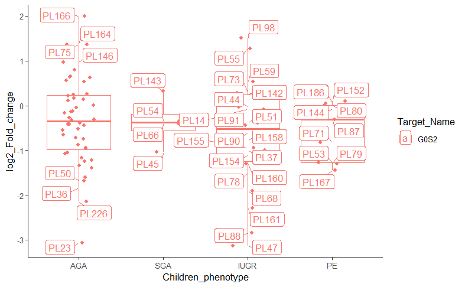

```r
b1 <-
  ggplot( merged_table3, aes(x=Children_phenotype, y=log2_Fold_change, color=Target_Name)) +
  geom_boxplot(outlier.shape=NA, position = position_dodge(0.8))+
  geom_point(position=position_jitterdodge())+
  geom_label_repel(
    min.segment.length = 0,
    mapping = aes(label = Sample_Name),
    position = position_dodge(0.7)
  )
b1
```

# ~ Plot for the paper ~

Change fonts for the plots.

```r
library(extrafont)
font_import()
y
```

[output not shown]

[output cut: 272 more lines]

[output not shown]

```r
loadfonts(device = "win")
```

[output not shown]

[output cut: 133 more lines]

[output not shown]

Initiate a ggplot, modify here.

```r
gene1 <- merged_table3 %>%
  filter(Target_Name %in% c('G0S2')) %>%
  ggplot(aes(x=Children_phenotype, y=log2_Fold_change))
```

Select the type of comparison for a test.

```r
#my_comparisons1 <- list(c('Male', 'Female'))
my_comparisons2 <- list(c('AGA', 'SGA'), c('AGA', 'IUGR'), c('AGA', 'PE'))
#my_comparisons3 <- list(c('AGA', 'IUGR'), c('AGA', 'PE'))
```

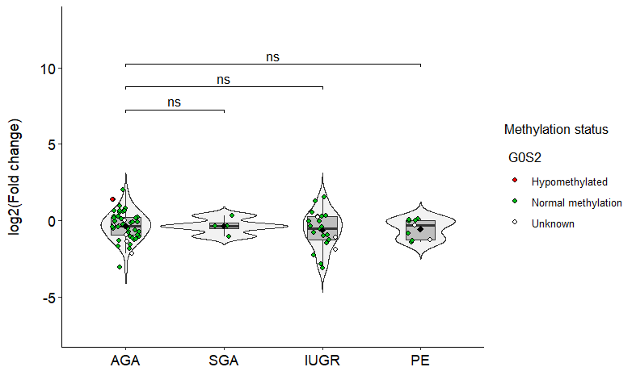

```r
## sets a theme
theme_set(
  theme_classic() +
    theme(legend.position = "right")
)

V4 <- gene1 +
  ## Adds a boxplot
  ## Adds a boxplot
  geom_violin( trim = FALSE, fill = "gray95", alpha=1, size=0.5,  width=1.3, position= position_dodge(0.8), cex=0.75 )+
  geom_boxplot(width = 0.3,fill = "gray75",  cex=0.75, alpha=1, lwd=0.5, outlier.shape = NA) +
  scale_y_continuous(limits=c(-7.3, 13))+
  xlab("") +
  ylab("log2(Fold change)\n")+
  #ggtitle("\n\n") +
  ## adjust points, can remove a legend
  geom_point(position=position_jitterdodge(jitter.width=0.7, dodge.width = 0), size=1.5, pch=21, aes(fill=factor(methyl_status)))+
  scale_fill_manual(name = "Methylation status\n\n G0S2", labels = c('Hypomethylated', 'Normal methylation', 'Unknown'),values = c("red", "#00be14ff", "white"))+
  stat_summary(fun.y="mean", color="black", shape=18, size=0.5)+
  stat_compare_means(comparisons = my_comparisons2, method = "wilcox", label.y = c(7, 8.5, 10), label = "p.signif", tip.length = 0.03, bracket.size = 0.5, size=4,
  symnum.args <- list(cutpoints = c(0, 0.0001, 0.001, 0.01, 0.05, 1), symbols = c("****", "***", "**", "*", "ns"), size=2))
V4_FINAL <- V4+
### sets a theme
theme_set(
  theme_classic() +
    theme(legend.position = "right", plot.margin = unit(c(0.1, 0.1, 0.1, 0.1), "inches")))+
      theme(plot.title = element_text(colour='Black', size=12, family='Arial',hjust = 0.5),
        axis.title.x = element_text(color='Black', size=12, family='Arial'),
        axis.title.y = element_text(color='Black', size=12, family='Arial'),
        axis.text.x = element_text(color='black', size=12, family='Arial'),
        axis.text.y = element_text(color='black', size=12, family='Arial'))


V4_FINAL
```

Removes the legend.

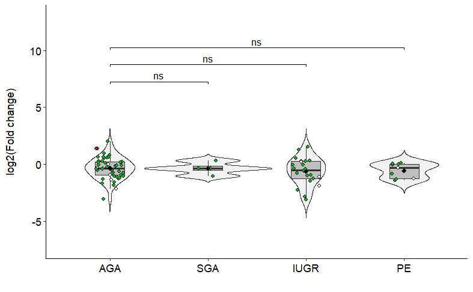

```r
V4_FINAL2 <- V4_FINAL + theme(legend.position="none")


V4_FINAL2
```

Makes the same size as for the other plots.

```r
figure4_with_legend <- ggarrange(V4_FINAL,
                     labels = c("E"),
                     ncol = 2, nrow = 2)+ ggtitle("")
```

[output not shown]

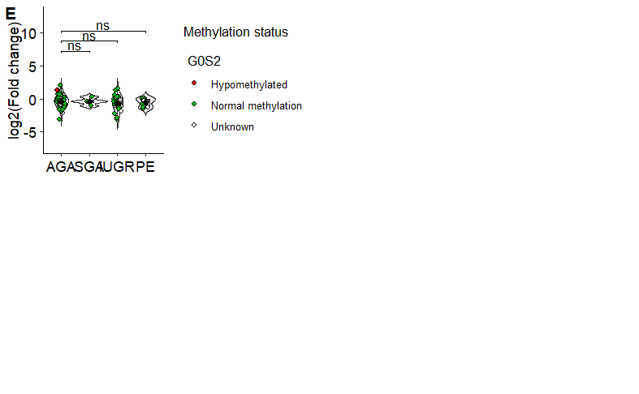

```r
figure4_with_legend
```

Without the legend.

```r
figure4 <- ggarrange(V4_FINAL2  ,
                     labels = c("E"),
                     ncol = 2, nrow = 2)+ ggtitle("")
```

[output not shown]

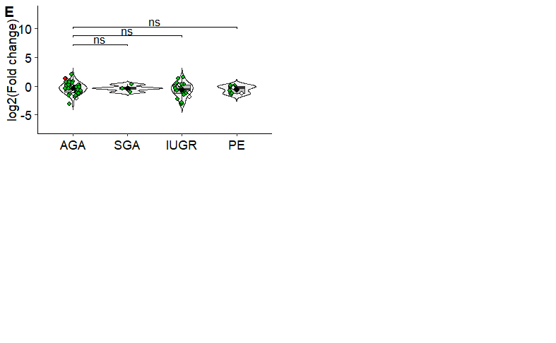

```r
figure4
```

# Correlation analysis methylation vs expression

```r
### removes samples from these columns that have NAs
correlation_table <- merged_table3 %>% drop_na(log2_Fold_change, CpG_average)

## splitting in individua groups
AGA <-merged_table3 %>% filter(Children_phenotype %in% c('AGA'))
AGA <- AGA %>% drop_na(log2_Fold_change, CpG_average)

SGA <-merged_table3 %>% filter(Children_phenotype %in% c('SGA'))
SGA <- SGA %>% drop_na(log2_Fold_change, CpG_average)

PE <-merged_table3 %>% filter(Children_phenotype %in% c('PE'))
PE <- PE %>% drop_na(log2_Fold_change, CpG_average)

IUGR <-merged_table3 %>% filter(Children_phenotype %in% c('IUGR'))
IUGR <- IUGR %>% drop_na(log2_Fold_change, CpG_average)
```

```r
shapiro.test(AGA$log2_Fold_change)
```

```
    Shapiro-Wilk normality test

data:  AGA$log2_Fold_change
W = 0.98956, p-value = 0.966
```

```r
shapiro.test(AGA$CpG_average)
```

```
    Shapiro-Wilk normality test

data:  AGA$CpG_average
W = 0.84613, p-value = 6.025e-05
```

```r
#
shapiro.test(SGA$log2_Fold_change)
```

```
    Shapiro-Wilk normality test

data:  SGA$log2_Fold_change
W = 0.95858, p-value = 0.77
```

```r
shapiro.test(SGA$CpG_average)
```

```
    Shapiro-Wilk normality test

data:  SGA$CpG_average
W = 0.92419, p-value = 0.5607
```

```r
#
shapiro.test(PE$log2_Fold_change)
```

```
    Shapiro-Wilk normality test

data:  PE$log2_Fold_change
W = 0.81084, p-value = 0.05234
```

```r
shapiro.test(PE$CpG_average)
```

```
    Shapiro-Wilk normality test

data:  PE$CpG_average
W = 0.78618, p-value = 0.02982
```

```r
#
shapiro.test(IUGR$log2_Fold_change)
```

```
    Shapiro-Wilk normality test

data:  IUGR$log2_Fold_change
W = 0.97015, p-value = 0.8006
```

```r
shapiro.test(IUGR$CpG_average)
```

```
    Shapiro-Wilk normality test

data:  IUGR$CpG_average
W = 0.96407, p-value = 0.6817
```

```r
## correlation test
cor(correlation_table$log2_Fold_change, correlation_table$CpG_average, method = 'spearman')
```

```
[1] -0.01618449
```

```r
## correlation test
cor(AGA$log2_Fold_change, AGA$CpG_average, method = 'spearman')
```

```
[1] 0.09477765
```

```r
cor(AGA$log2_Fold_change, AGA$CpG_average, method = 'kendall')
```

```
[1] 0.09151924
```

```r
cor(SGA$log2_Fold_change, SGA$CpG_average, method = 'spearman')
```

```
[1] 0.8
```

```r
cor(SGA$log2_Fold_change, SGA$CpG_average, method = 'spearman')
```

```
[1] 0.8
```

```r
cor(PE$log2_Fold_change, PE$CpG_average, method = 'spearman')
```

```
[1] 0.3928571
```

```r
cor(PE$log2_Fold_change, PE$CpG_average, method = 'spearman')
```

```
[1] 0.3928571
```

```r
cor(IUGR$log2_Fold_change, IUGR$CpG_average, method = 'spearman')
```

```
[1] -0.2920537
```

Reorder table.

```r
correlation_table <- correlation_table[order(correlation_table$CpG_average),]
```

Making sample names as factors.

```r
correlation_table$Sample_Name <- as.factor(correlation_table$Sample_Name)
```

Reorder factors or samples based on the methylation level, mean. #https://www.r-graph-gallery.com/267-reorder-a-variable-in-ggplot2.html

```r
correlation_table$Sample_Name = with(correlation_table, reorder(Sample_Name,correlation_table$CpG_average))
```

# Scatter plot

One regression line for all phenotypes.

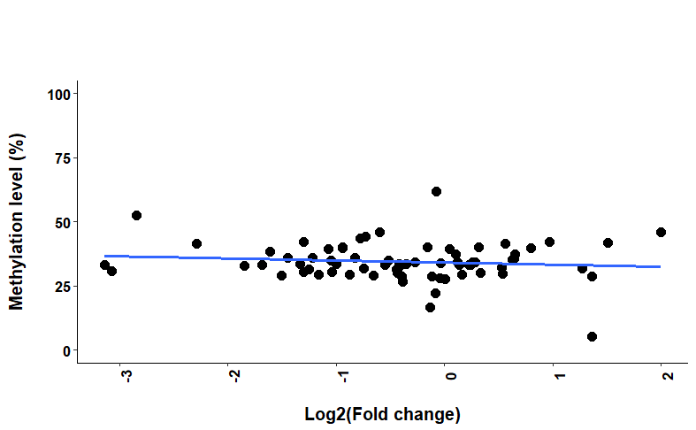

```r
theme_set(
  theme_classic() +
    theme(legend.position = "right")
)

gene <-
  ggplot(correlation_table, aes(x=log2_Fold_change, y=CpG_average))

groups <-
  gene +
  geom_point( size=3)+
  geom_smooth(method="lm", se = FALSE)+
#  geom_line(data=correlation_table, aes(x=log2_Fold_change, y=  CpG_average, color= Children_phenotype))+ xlab("\n log2(Fold change)") +
  ylim(0, 100)+
  scale_fill_brewer(palette="Dark2")+
  ylab("Methylation level (%)\n")+
  xlab('\nLog2(Fold change)')+
  ggtitle("\n\n") +
  ## Adjustdjust title, x and y labels, and x and y axis text
  theme(plot.title = element_text(colour='Black', size=16, face='bold', family='Courier',
                                  hjust = 0.5),
        axis.title.x = element_text(color='Black', size=13, face="bold", family='Courier'),
        axis.title.y = element_text(color='Black', size=13, face="bold", family='Courier'),
        axis.text.x = element_text(face='bold', color='black', size=11, angle = 90),
        axis.text.y = element_text(face='bold', color='black', size=11))
groups
```

Several regression lines for each phenotype.

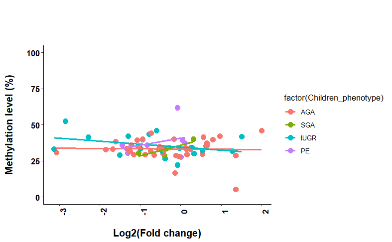

```r
## sets a theme
theme_set(
  theme_classic() +
    theme(legend.position = "right")
)

gene <-
  ggplot(correlation_table, aes(x=log2_Fold_change, y=CpG_average, color= factor(Children_phenotype)))

groups <-
  gene +
  geom_point( size=3)+
  geom_smooth(method="lm", se = FALSE)+
  #geom_line(data=correlation_table, aes(x=log2_Fold_change, y=  CpG_average, color= Children_phenotype))+ xlab("\n log2(Fold change)") +
  ylim(0, 100)+
  scale_fill_brewer(palette="Dark2")+
  ylab("Methylation level (%)\n")+
  xlab('\nLog2(Fold change)')+
  ggtitle("\n\n") +
  ## Adjustdjust title, x and y labels, and x and y axis text
  theme(plot.title = element_text(colour='Black', size=16, face='bold', family='Courier',
                                  hjust = 0.5),
        axis.title.x = element_text(color='Black', size=13, face="bold", family='Courier'),
        axis.title.y = element_text(color='Black', size=13, face="bold", family='Courier'),
        axis.text.x = element_text(face='bold', color='black', size=11, angle = 90),
        axis.text.y = element_text(face='bold', color='black', size=11))
groups
```

Check if other non-linear models fit the data better.

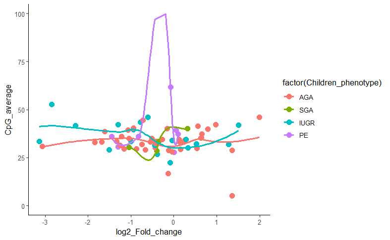

```r
gene <-
  ggplot(correlation_table, aes(x=log2_Fold_change, y=CpG_average, color=factor(Children_phenotype)))+
  geom_point( size=3)+
  ylim(0, 100)+
  geom_smooth(method="loess", se = FALSE)

gene
```